# Business_Statistics-Project

## Project Objective

Statistical Analysis of Business Data. Explore the dataset and extract insights from the data.

Key Questions to answer:

1. Explore the dataset and extract insights using Exploratory Data Analysis.
2. Prove(or disprove) that the medical claims made by the people who smoke is greater than those who don't?
3. Prove (or disprove) with statistical evidence that the BMI of females is different from that of males.
4. Is the proportion of smokers significantly different across different regions?
5. Is the mean BMI of women with no children, one child and two children the same? Explain your answer with statistical evidence.

### About the data-

1. Age - This is an integer indicating the age of the primary beneficiary (excluding those above 64 years, since they are generally covered by the government).
2. Sex - This is the policy holder's gender, either male or female.
3. BMI - This is the body mass index (BMI), which provides a sense of how over or under-weight a person is relative to their height. BMI is equal to weight (in kilograms) divided by height (in meters) squared. An ideal BMI is within the range of 18.5 to 24.9.
4. Children - This is an integer indicating the number of children / dependents covered by the insurance plan.
5. Smoker - This is yes or no depending on whether the insured regularly smokes tobacco.
6. Region - This is the beneficiary's place of residence in the U.S., divided into four geographic regions - northeast, southeast, southwest, or northwest.
7. Charges - Individual medical costs billed by health insurance

## Exploratory Data Analysis - Step by step approach

Typical Data exploration activity consists of the following steps:

1. Importing Data
2. Variable Identification
3. Univariate Analysis
4. Bi-Variate Analysis
5. Variable Transformation / Feature Creation

```python
%matplotlib inline
import numpy as np
import pandas as pd
from matplotlib import pyplot as plt
import seaborn as sns
# import statsmodels.api as sm
import scipy.stats as stats
from sklearn.preprocessing import LabelEncoder
import copy
import warnings

warnings.filterwarnings("ignore")
```

```python
sns.set()
```

```python
data = pd.read_csv(r'C:\Users\davis\OneDrive\Desktop\Python\Business Stats\AxisInsurance.csv')
```

```python
data.head()
```

|  | age | sex | bmi | children | smoker | region | charges |
| --- | --- | --- | --- | --- | --- | --- | --- |
| 0 | 19 | female | 27.900 | 0 | yes | southwest | 16884.92400 |
| 1 | 18 | male | 33.770 | 1 | no | southeast | 1725.55230 |
| 2 | 28 | male | 33.000 | 3 | no | southeast | 4449.46200 |
| 3 | 33 | male | 22.705 | 0 | no | northwest | 21984.47061 |
| 4 | 32 | male | 28.880 | 0 | no | northwest | 3866.85520 |

```python
data.tail()
```

|  | age | sex | bmi | children | smoker | region | charges |
| --- | --- | --- | --- | --- | --- | --- | --- |
| 1333 | 50 | male | 30.97 | 3 | no | northwest | 10600.5483 |
| 1334 | 18 | female | 31.92 | 0 | no | northeast | 2205.9808 |
| 1335 | 18 | female | 36.85 | 0 | no | southeast | 1629.8335 |
| 1336 | 21 | female | 25.80 | 0 | no | southwest | 2007.9450 |
| 1337 | 61 | female | 29.07 | 0 | yes | northwest | 29141.3603 |

```python
data.shape
```

```
(1338, 7)
```

Dataset has 1338 rows, and 7 columns.

```python
data.info()
```

```
<class 'pandas.core.frame.DataFrame'>
RangeIndex: 1338 entries, 0 to 1337
Data columns (total 7 columns):
 #   Column    Non-Null Count  Dtype
---  ------    --------------  -----
 0   age       1338 non-null   int64
 1   sex       1338 non-null   object
 2   bmi       1338 non-null   float64
 3   children  1338 non-null   int64
 4   smoker    1338 non-null   object
 5   region    1338 non-null   object
 6   charges   1338 non-null   float64
dtypes: float64(2), int64(2), object(3)
memory usage: 73.3+ KB
```

Sex, smoker, and region change to categories.

```python
data["sex"]=data["sex"].astype("category")
data["smoker"]=data["smoker"].astype("category")
data["region"]=data["region"].astype("category")
```

```python
data.isna().sum()
```

```
age         0
sex         0
bmi         0
children    0
smoker      0
region      0
charges     0
dtype: int64
```

No missing values.

```python
data.describe().T
```

|  | count | mean | std | min | 25% | 50% | 75% | max |
| --- | --- | --- | --- | --- | --- | --- | --- | --- |
| age | 1338.0 | 39.207025 | 14.049960 | 18.0000 | 27.00000 | 39.000 | 51.000000 | 64.00000 |
| bmi | 1338.0 | 30.663397 | 6.098187 | 15.9600 | 26.29625 | 30.400 | 34.693750 | 53.13000 |
| children | 1338.0 | 1.094918 | 1.205493 | 0.0000 | 0.00000 | 1.000 | 2.000000 | 5.00000 |
| charges | 1338.0 | 13270.422265 | 12110.011237 | 1121.8739 | 4740.28715 | 9382.033 | 16639.912515 | 63770.42801 |

- No major issues with the dataset indicated.
- 75% of the people have 2 or less children

```python
data.describe(include=["category"])
```

|  | sex | smoker | region |
| --- | --- | --- | --- |
| count | 1338 | 1338 | 1338 |
| unique | 2 | 2 | 4 |
| top | male | no | southeast |
| freq | 676 | 1064 | 364 |

# Univariate Analysis

```python
def histogram_boxplot(data, xlabel = None, title = None, font_scale=2, figsize=(15,7), bins = None):
    """ Boxplot and histogram combined
    data: 1-d data array
    xlabel: xlabel
    title: title
    font_scale: the scale of the font (default 2)
    figsize: size of fig (default (9,8))
    bins: number of bins (default None / auto)


    """
    mean = np.mean(data)

    sns.set(font_scale=font_scale)
    f2, (ax_box2, ax_hist2) = plt.subplots(2, sharex=True, gridspec_kw={"height_ratios": (.25, .75)}, figsize=figsize)
    sns.boxplot(data, ax=ax_box2,showmeans=True,color="violet")
    sns.distplot(data,kde=False, ax=ax_hist2, bins=bins,palette="winter") if bins else sns.distplot(data,kde=False, ax=ax_hist2,color="black")
    ax_hist2.axvline(mean, color='g', linestyle='--')
    if xlabel: ax_hist2.set(xlabel=xlabel)
    if title: ax_box2.set(title=title)
    plt.show()
```

Age

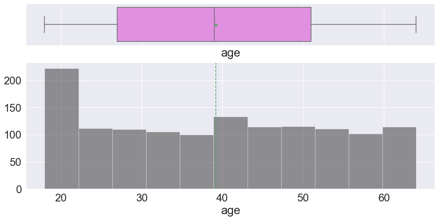

```python
histogram_boxplot(data["age"])
```

BMI

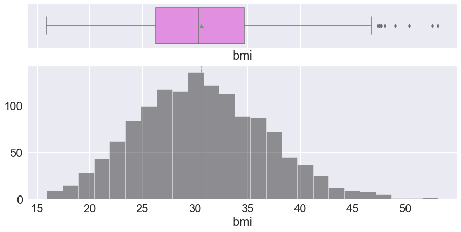

```python
histogram_boxplot(data["bmi"])
```

Normal distribution.

Children

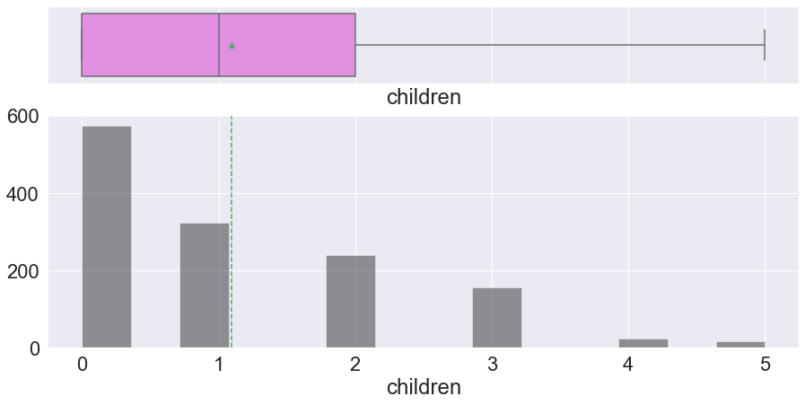

```python
histogram_boxplot(data["children"])
```

```python
data['children'] = data['children'].astype('category')
```

Charges

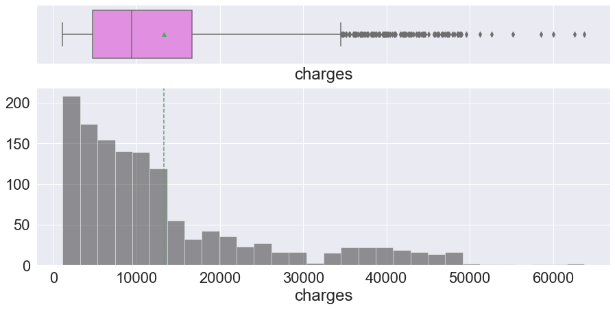

```python
histogram_boxplot(data["charges"])
```

- Right skewed distribution. The mean charges is higher than the median charges
- Outliers towards the higher end.

```python
def perc_on_bar(plot, feature):
    '''
    plot
    feature: categorical feature
    the function won't work if a column is passed in hue parameter
    '''
    total = len(feature)
    for p in ax.patches:
        percentage = '{:.1f}%'.format(100 * p.get_height()/total)
        x = p.get_x() + p.get_width() / 2 - 0.05
        y = p.get_y() + p.get_height()
        ax.annotate(percentage, (x, y), size = 12)
    plt.show()
```

Sex

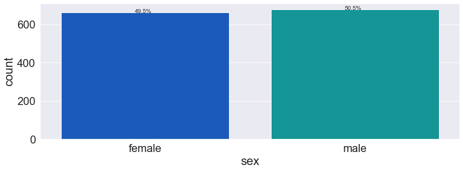

```python
plt.figure(figsize=(15,5))
ax = sns.countplot(data["sex"],palette='winter')
perc_on_bar(ax,data["sex"])
```

Distribution of observations is similar.

Children

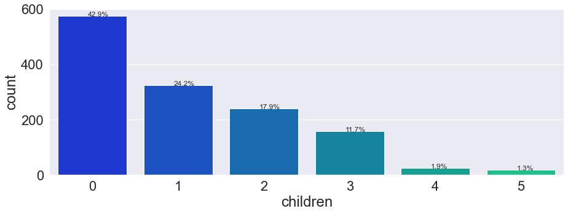

```python
plt.figure(figsize=(15,5))
ax = sns.countplot(data["children"],palette='winter')
perc_on_bar(ax,data["children"])
```

Smoker

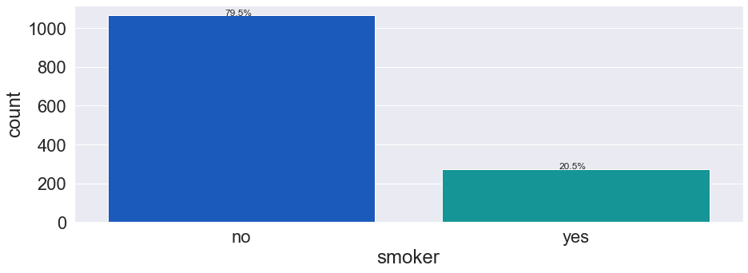

```python
plt.figure(figsize=(15,5))
ax = sns.countplot(data["smoker"],palette='winter')
perc_on_bar(ax,data["smoker"])
```

Only 20% of customers are smokers.

Region

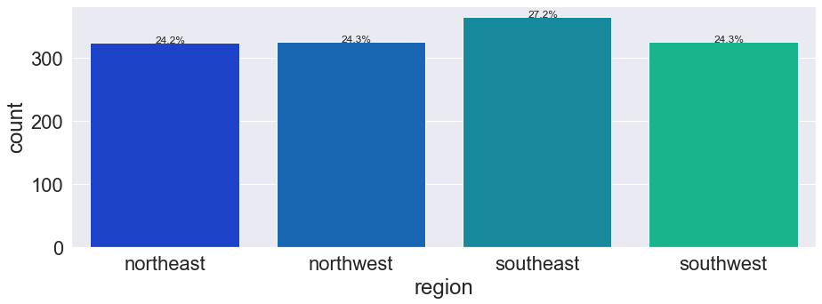

```python
plt.figure(figsize=(15,5))
ax = sns.countplot(data["region"],palette='winter')
perc_on_bar(ax,data["region"])
```

Regions are fairly equally distributed.

# Bivariate Analysis

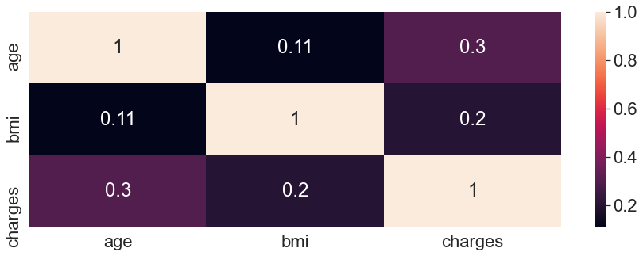

```python
plt.figure(figsize=(15,5))
sns.heatmap(data.corr(),annot=True)
plt.show()
```

Not much correlation indicated.

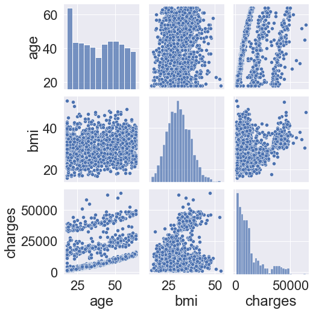

```python
sns.pairplot(data)
plt.show()
```

# 2.Prove or disprove that the medical claims made by the people who smoke is greater than those who don't?

```python
data.smoker.value_counts()
```

```
no     1064
yes     274
Name: smoker, dtype: int64
```

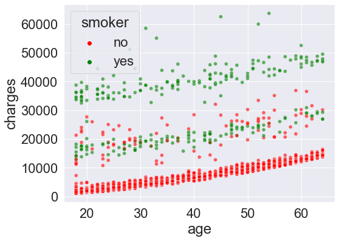

```python
plt.figure(figsize=(8,6))
sns.scatterplot(data.age, data.charges,hue=data.smoker,palette= ['red','green'] ,alpha=0.6)
plt.show()
```

### T-test to check dependency of charges on smoking attribute

Null Hypothesis = Ho = "Mean charges of smokers is less than or equal to non-smokers."

Alternate Hypothesis = Ha = "Mean charges of smokers is greater than non-smokers."

This will be a one-tailed t-test.

`Significance Level = 0.05`

```python
Ho = "Mean charges of smokers is less than or equal to non-smokers"
Ha = "Mean charges of smokers is greater than non-smokers"


x = np.array(data[data.smoker == 'yes'].charges)
y = np.array(data[data.smoker == 'no'].charges)

t, p_value  = stats.ttest_ind(x,y)
```

```python
p_value=p_value/2
print("Tstat:",t,"P-value:",p_value)
```

```
Tstat: 46.664921172723716 P-value: 4.1357179210886093e-283
```

```python
if p_value < 0.05:
    print(f'{Ha} as the p_value ({p_value}) < 0.05')
else:
    print(f'{Ho} as the p_value ({p_value}) > 0.05')
```

```
Mean charges of smokers is greater than non-smokers as the p_value (4.1357179210886093e-283) < 0.05
```

Mean charges by smokers are higher than non-smokers.

## 3.Prove or disprove with statistical evidence that BMI of females is different from that of males.

```python
data.sex.value_counts()
```

```
male      676
female    662
Name: sex, dtype: int64
```

BMI of females

```python
np.mean(data[data.sex == 'female'].bmi)
```

```
30.377749244713023
```

BMI of males

```python
np.mean(data[data.sex == 'male'].bmi)
```

```
30.943128698224832
```

In the sample, the mean BMI of males is greater than females. Will need to perform a t-test to check if this result is statistically significant or just by random chance.

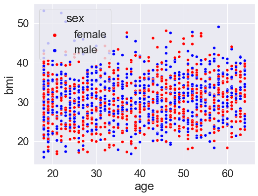

```python
plt.figure(figsize=(8,6))
sns.scatterplot(data.age, data.bmi,hue=data.sex,palette= ['red','blue'] )
plt.show()
```

No relation between gender and BMI.

### T-test to check dependency of BMI on gender attribute

Null Hypothesis = Ho = "Mean BMI of females is same as that of males"

Alternate Hypothesis = Ha = "Mean BMI of females is different from males"

This will be a two-tailed t-test.

`Significance Level = 0.05`

```python
Ho = "BMI Females is same as BMI Males"
Ha = "BMI Females is different from BMI Males"

x = np.array(data[data.sex == 'male'].bmi)
y = np.array(data[data.sex == 'female'].bmi)

t, p_value  = stats.ttest_ind(x,y)

if p_value < 0.05:
    print("Reject the Null Hypothesis that the BMI Females same as that of BMI Males")
else:
    print("Failed to reject the Null Hypothesis that the BMI Females is same as that of BMI Males")
```

```
Failed to reject the Null Hypothesis that the BMI Females is same as that of BMI Males
```

No statistical differences in BMI for males and females.

## 4. Is the proportion of smokers significantly different across different regions?

```python
pd.crosstab(data['smoker'],data['region'])
```

| region smoker | northeast | northwest | southeast | southwest |
| --- | --- | --- | --- | --- |
| no | 257 | 267 | 273 | 267 |
| yes | 67 | 58 | 91 | 58 |

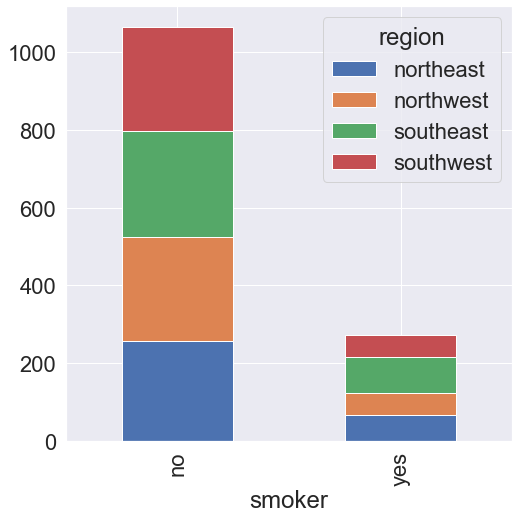

```python
pd.crosstab(data['smoker'],data['region']).plot(kind="bar", figsize=(8,8),
                 stacked=True)
```

- The proportion of smokers in southeast region is higher than others.

### Chi-sq test to check if smoking habits are different for different regions

Null Hypothesis = Ho = "Region has no effect on smoking habits"

Alternate Hypothesis = Ha = "Region has an effect on smoking habits"

`Significance Level = 0.05`

```python
Ho = "Region has no effect on smoking habits"
Ha = "Region has an effect on smoking habits"

crosstab = pd.crosstab(data['region'],data['smoker'])

chi, p_value, dof, expected =  stats.chi2_contingency(crosstab)

if p_value < 0.05:
    print(f'{Ha} as the p_value ({p_value.round(3)}) < 0.05')
else:
    print(f'{Ho} as the p_value ({p_value.round(3)}) > 0.05')
```

```
Region has no effect on smoking habits as the p_value (0.062) > 0.05
```

- Proportion of smokers across different regions is same.

## 5. Is the mean BMI of women with no children, one child and two children the same? Explain your answer with statistical evidence.

```python
data.groupby(['sex','children'])['bmi'].mean()
```

```
sex     children
female  0           30.361522
        1           30.052658
        2           30.649790
        3           30.436429
        4           31.943182
        5           30.620625
male    0           30.741719
        1           31.166145
        2           31.300992
        3           30.922937
        4           30.957500
        5           28.792500
Name: bmi, dtype: float64
```

## Aanalysis of variance test (ANOVA) to check if bmi values for females having different number of children, are significantly different

Null Hypothesis = Ho = "No. of children has no effect on bmi"

Alternate Hypothesis = Ha = "No. of children has an effect on bmi"

`Significance Level = 0.05`

```python
Ho = "No. of children has no effect on bmi"
Ha = "No. of children has an effect on bmi"

female_data = data[data['sex'] == 'female']

zero = female_data[female_data.children == 0]['bmi']
one = female_data[female_data.children == 1]['bmi']
two = female_data[female_data.children == 2]['bmi']


f_stat, p_value = stats.f_oneway(zero,one,two)


if p_value < 0.05:  # Setting our significance level at 5%
    print(f'{Ha} as the p_value ({p_value.round(3)}) < 0.05')
else:
    print(f'{Ho} as the p_value ({p_value.round(3)}) > 0.05')
```

```
No. of children has no effect on bmi as the p_value (0.716) > 0.05
```

- We failed to reject the Null Hypothesis. The mean BMI of women with different number of children is not statistically different.

# Conclusion

- The claims made by smokers are higher as compared to non-smokers. Company should create personalized policies for these customer smokers and non-smokers
- Very few people have more than 2 children. 75% of the people have 2 or less children. However number of children has no affect on BMI of the female customers.
- BMI has a slight positive correlation with the medical claims.